# Visualization of Crop and Livestock products

INFO 526 - Fall 2024 - Project 01

Project description

Author

Affiliation

VizCats

School of Information, University of Arizona

## Abstract

This project focuses on compiling and analyzing statistical data for a diverse range of 278 crop and livestock products. The dataset will be expressed in key indicators like production quantities, yields, and processed product outputs, making it a valuable resource for understanding global agricultural production patterns across crops and livestock industries.

## Introduction

This report analyzes the FAOSTAT Crop and Livestock Production dataset, which provides global agricultural production statistics across more than 200 countries. The dataset covers crop production volumes, harvested areas, and yields, alongside livestock statistics. The objective of this project is to explore trends in agricultural productivity, compare regional outputs, and assess the sustainability of agricultural practices.

## Source of the Data

The data used in this report is curated by the Food and Agriculture Organization (FAO) of the United Nations, through their FAOSTAT database. It includes data collected annually since 1961 from government sources, surveys, and FAO estimates. website link : https://www.fao.org/faostat/en/#data/QCL

## Data Collection

The dataset is compiled from official reports from national statistical offices, and in cases of missing data, FAO uses estimation methods. This ensures consistency in the data for over 200 countries and regions.

## Column Observations

The dataset consists of 79,381 rows and 195 columns. Each row represents the production data for a specific commodity in a given country and year. The key variables include:

- **Area**: Country or region.
- **Item**: Commodity (e.g., wheat, rice, livestock).
- **Element**: Type of data (e.g., production, area harvested).
- **Year**: Year of the observation.
- **Yxxxx**: Yearly production data. (e.g., Y1961, Y1962), where xxxx is the year.
- **Value**: Recorded production value.

## Exploratory Data Analysis (EDA)

We took a number of measures to carry out inspection, cleaning, and visualization of the data effectively, which in turn enables us to conduct analysis regarding livestock production trends and its regional distribution.

1. **Data Inspection**

Understanding the structure and content of a dataset is essential, so this method consisted of loading and examining the dataset. The dataset consists of several columns, including:

Area: Refers to the country or region.

Item: Denotes the specific livestock commodity (e.g., Beef, Poultry, Milk).

Element: Represents the type of data, such as “Production,” “Area harvested,” or “Yield.”

Year: The year of the data.

Value: The production value (in tons, hectares, etc.) for the specified year and item.

Examination of the dataset produced values that were relatively substantial as the data collected covered a period of several decades.

2. **Data Cleaning**

For such cleaning operations, we focused removal of rows containing missing values on key columns such as Area, Item and Element. This step ensured that the analysis concentrated on completed records only without any other missing or non-relevant information.

Post- cleaning, the data was arranged in such a manner that Year and Item columns served as the grouping variables while Value was used to denote the total production or harvested area for that year and item.

3. **Distribution of Livestock Holding Items**

The first insight was in livestock items distribution across the locations in the database. The commonest items cut across include beef, poultry, milk and pork, which form the leading lines in the livestock production for the world. This distribution gives an idea of the intensity of different types of livestock kept and can be useful in the later analysis by helping to establish in which region which commodities are most produced.

4. **product Data Description**

We created an item-centric cross -section in the dataset for ”Production” data by such years. This brought out the perspective of total production for each livestock commodity in the course of time. The total amounts of production of every commodity were in estimates, which enabled the study to observe which livestock product had the biggest global turnovers in livestock production.

## Methodology

This analysis examines the trends in global livestock production based on information from the FAOSTAT database focusing on several commodities, namely beef, poultry, and milk. Generally, a technique is conceived in terms of

1. **Data Collection** Sourcing data basically from the FAOSTAT Crop and Livestock Production dataset, including volumes produced, harvested areas, and yields from various livestock commodities across the world of more than 200 countries.

Key datasets carried out for the analysis included:

Production_Crops_Livestock_E_All_Data.csv: It comprises production data for multiple livestock commodities. Production_Crops_Livestock_E_AreaCodes.csv: It provides the area (country) codes and names. Production_Crops_Livestock_E_Elements.csv: It provides the respective observations of various elements (production, area harvested, yield). Production_Crops_Livestock_E_ItemCodes.csv: It gives codes and descriptions of each component of livestock (i.e., Beef, Poultry, Milk).

## Results

[figure not shown]

[figure not shown]

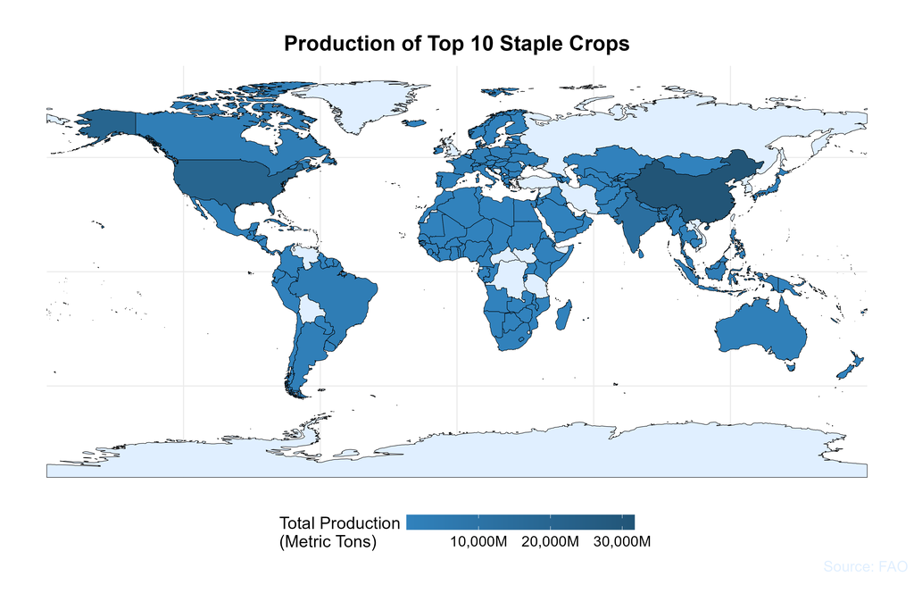

## Discussion

The study identifies some inefficiencies and environmental challenges of large-scale livestock production among the largest producers in the world, but it highlights the need for more sustainable practices. Additionally, livestock trade plays a very important role, with countries like Brazil and Australia putting their stamp on the production dynamics of the world.

The findings highlight that policymakers have to encourage sustainability and efficiency in livestock farming, alongside optimizing the consequences on the environment. Further research may deal with the effects of climate change and alternatives to conventional livestock products.

## Future work

Future research sectors should focus on studies that would assess the impact of climate change on crops yield and livestock production in especially vulnerable regions. Also, it is imperative to explore alternative and sustainable livestock practices and alternative sources of protein to reduce the environmental impacts. More investigations will fill in the gap on policy interventions and international trades that shape global livestock production trends and how one balances production efficiencies with sustainability. Lastly, further social inquiry would consider the potential effects of technological innovations in animal farming on global production dynamics.